# AML_Analysis

B. Oztas, D. Cetinkaya, F. Adedoyin, M. Budka, H. Dogan and G. Aksu, "Enhancing Anti-Money Laundering: Development of a Synthetic Transaction Monitoring Dataset," 2023 IEEE International Conference on e-Business Engineering (ICEBE), Sydney, Australia, 2023, pp. 47-54, doi: 10.1109/ICEBE59045.2023.00028. https://ieeexplore.ieee.org/document/10356193

Money laundering remains a significant global issue, driving the need for improved transaction monitoring methods. Current anti-money laundering (AML) procedures are inefficient, and access to data is difficult/restricted by legal and privacy issues. Moreover, existing data often lacks diversity and true labels. This study introduces a novel AML transaction generator, creating the SAML-D dataset with enhanced features and typologies, aiming to aid researchers in evaluating their models and developing more advanced monitoring methods.

The dataset incorporates 12 features and 28 typologies (split between 11 normal and 17 suspicious). These were selected based on existing datasets, the academic literature, and interviews with AML specialists. The dataset comprises 9,504,852 transactions, of which 0.1039% are suspicious. It also includes 15 graphical network structures to represent the transaction flow within these typologies. The structures, while sometimes shared among typologies, vary significantly in parameters to increase complexities and challenge detection efforts. More details about these typologies are available in the paper above. The dataset is an updated version compared to the paper.

Features of the SAML-D dataset:

• Time and Date: Essential for tracking transaction chronology.

• Sender and Receiver Account Details: Helps uncover behavioural patterns and complex banking connections.

• Amount: Indicates transaction values to identify suspicious activities.

• Payment Type: Includes various methods like credit card, debit card, cash, ACH transfers, cross-border, and cheque.

• Sender and Receiver Bank Location: Pinpoints high-risk regions including Mexico, Turkey, Morocco, and the UAE.

• Payment and Receiver Currency: Align with location features, adding complexity when mismatched.

• 'Is Suspicious' Feature: Binary indicator differentiating normal from suspicious transactions.

• Type: Classifies typologies, offering deeper insights.

```python
import pandas as pd
import plotly.express as px
import numpy as np
import matplotlib.pyplot as plt
%matplotlib inline
import math
from PIL import Image
from scipy.stats import skew
from matplotlib.transforms import Bbox
import warnings
warnings.filterwarnings("ignore")
import plotly.graph_objects as go
from plotly.subplots import make_subplots
import seaborn as sns
from scipy.stats import skew, gaussian_kde
from sklearn import preprocessing
```

```python
df = pd.read_csv("SAML-D.csv")
```

```python
df.shape
```

```
(9504852, 12)
```

```python
df.info()
```

```
<class 'pandas.core.frame.DataFrame'>
RangeIndex: 9504852 entries, 0 to 9504851
Data columns (total 12 columns):
 #   Column                  Dtype
---  ------                  -----
 0   Time                    object
 1   Date                    object
 2   Sender_account          int64
 3   Receiver_account        int64
 4   Amount                  float64
 5   Payment_currency        object
 6   Received_currency       object
 7   Sender_bank_location    object
 8   Receiver_bank_location  object
 9   Payment_type            object
 10  Is_laundering           int64
 11  Laundering_type         object
dtypes: float64(1), int64(3), object(8)
memory usage: 870.2+ MB
```

```python
df.head()
```

|  | Time | Date | Sender_account | Receiver_account | Amount | Payment_currency | Received_currency | Sender_bank_location | Receiver_bank_location | Payment_type | Is_laundering | Laundering_type |
| --- | --- | --- | --- | --- | --- | --- | --- | --- | --- | --- | --- | --- |
| 0 | 10:35:19 | 2022-10-07 | 8724731955 | 2769355426 | 1459.15 | UK pounds | UK pounds | UK | UK | Cash Deposit | 0 | Normal_Cash_Deposits |
| 1 | 10:35:20 | 2022-10-07 | 1491989064 | 8401255335 | 6019.64 | UK pounds | Dirham | UK | UAE | Cross-border | 0 | Normal_Fan_Out |
| 2 | 10:35:20 | 2022-10-07 | 287305149 | 4404767002 | 14328.44 | UK pounds | UK pounds | UK | UK | Cheque | 0 | Normal_Small_Fan_Out |
| 3 | 10:35:21 | 2022-10-07 | 5376652437 | 9600420220 | 11895.00 | UK pounds | UK pounds | UK | UK | ACH | 0 | Normal_Fan_In |
| 4 | 10:35:21 | 2022-10-07 | 9614186178 | 3803336972 | 115.25 | UK pounds | UK pounds | UK | UK | Cash Deposit | 0 | Normal_Cash_Deposits |

```python
## Converting date into datetime format

df['Date'] = pd.to_datetime(df['Date'])

# Extract month, day, and week

df['Year'] = pd.to_datetime(df['Date']).dt.year
df['Month'] = pd.to_datetime(df['Date']).dt.month
df['Day'] = pd.to_datetime(df['Date']).dt.day
df['Week'] = df['Date'].dt.isocalendar().week
```

```python
df.head()
```

|  | Time | Date | Sender_account | Receiver_account | Amount | Payment_currency | Received_currency | Sender_bank_location | Receiver_bank_location | Payment_type | Is_laundering | Laundering_type | Year | Month | Day | Week |
| --- | --- | --- | --- | --- | --- | --- | --- | --- | --- | --- | --- | --- | --- | --- | --- | --- |
| 0 | 10:35:19 | 2022-10-07 | 8724731955 | 2769355426 | 1459.15 | UK pounds | UK pounds | UK | UK | Cash Deposit | 0 | Normal_Cash_Deposits | 2022 | 10 | 7 | 40 |
| 1 | 10:35:20 | 2022-10-07 | 1491989064 | 8401255335 | 6019.64 | UK pounds | Dirham | UK | UAE | Cross-border | 0 | Normal_Fan_Out | 2022 | 10 | 7 | 40 |
| 2 | 10:35:20 | 2022-10-07 | 287305149 | 4404767002 | 14328.44 | UK pounds | UK pounds | UK | UK | Cheque | 0 | Normal_Small_Fan_Out | 2022 | 10 | 7 | 40 |
| 3 | 10:35:21 | 2022-10-07 | 5376652437 | 9600420220 | 11895.00 | UK pounds | UK pounds | UK | UK | ACH | 0 | Normal_Fan_In | 2022 | 10 | 7 | 40 |
| 4 | 10:35:21 | 2022-10-07 | 9614186178 | 3803336972 | 115.25 | UK pounds | UK pounds | UK | UK | Cash Deposit | 0 | Normal_Cash_Deposits | 2022 | 10 | 7 | 40 |

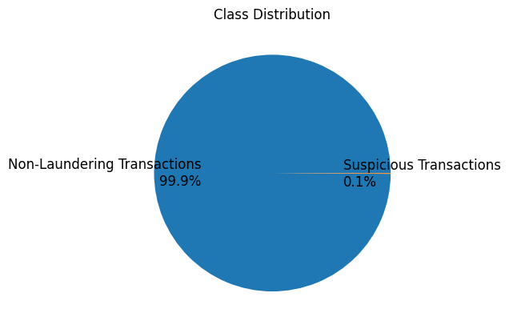

```
Is_laundering
0    9494979
1       9873
Name: count, dtype: int64
```

```python
pie_data = df['Is_laundering'].value_counts().reset_index()
pie_data.columns = ['Class', 'Count']
pie_data['Class'] = pie_data['Class'].map({0: 'Non-Laundering Transactions', 1: 'Suspicious Transactions'})

total = pie_data['Count'].sum()
percentages = 100. * pie_data['Count'] / total
labels = [f"{cls}\n{pct:.1f}%" for cls, pct in zip(pie_data['Class'], percentages)]

plt.pie(pie_data['Count'], labels=labels, labeldistance=0.6, textprops={'fontsize': 12})
plt.title('Class Distribution')
plt.show()

print(df['Is_laundering'].value_counts())
```

```
           Laundering_type    count
0     Normal_Small_Fan_Out  3477717
1           Normal_Fan_Out  2302220
2            Normal_Fan_In  2104285
3             Normal_Group   528351
4   Normal_Cash_Withdrawal   305031
5     Normal_Cash_Deposits   223801
6        Normal_Periodical   210526
7       Normal_Plus_Mutual   155041
8            Normal_Mutual   125335
9            Normal_Foward    42031
10     Normal_single_large    20641
11             Structuring     1870
12         Cash_Withdrawal     1334
13            Deposit-Send      945
14                Smurfing      932
15          Layered_Fan_In      656
16         Layered_Fan_Out      529
17       Stacked Bipartite      506
18    Behavioural_Change_1      394
19               Bipartite      383
20                   Cycle      382
21                  Fan_In      364
22          Gather-Scatter      354
23    Behavioural_Change_2      345
24          Scatter-Gather      338
25            Single_large      250
26                 Fan_Out      237
27          Over-Invoicing       54
```

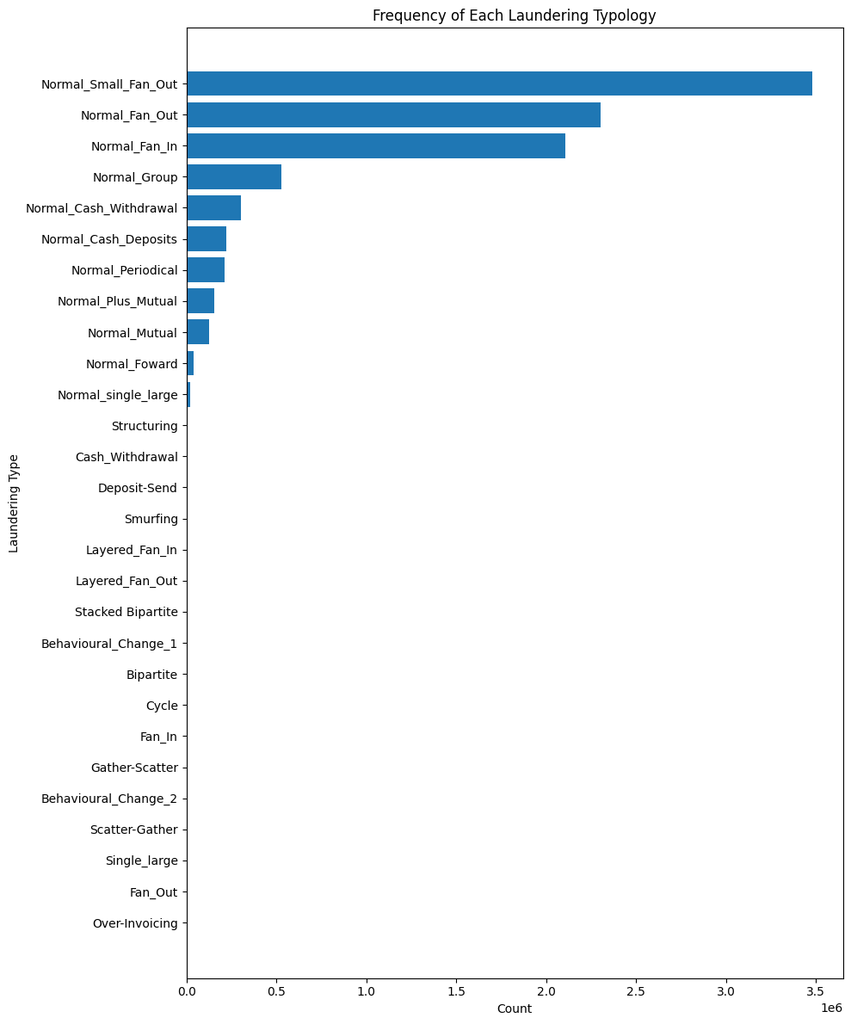

```python
laundering_type_counts = df['Laundering_type'].value_counts().reset_index()
laundering_type_counts.columns = ['Laundering_type', 'count']
print(laundering_type_counts)
laundering_type_counts = laundering_type_counts.sort_values('count', ascending=False)

plt.figure(figsize=(10, 12))  # Adjust height for many categories
plt.barh(laundering_type_counts['Laundering_type'][::-1], laundering_type_counts['count'][::-1])
plt.xlabel('Count')
plt.ylabel('Laundering Type')
plt.title('Frequency of Each Laundering Typology')
plt.tight_layout()
plt.show()
```

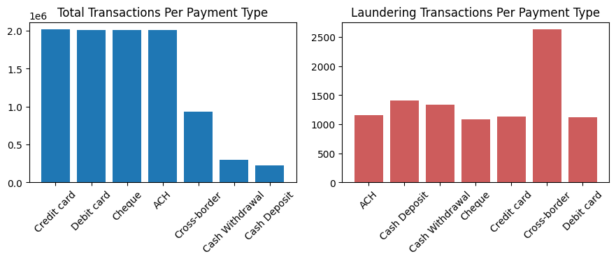

```
Payment_type
Credit card        2012909
Debit card         2012103
Cheque             2011419
ACH                2008807
Cross-border        933931
Cash Withdrawal     300477
Cash Deposit        225206
Name: count, dtype: int64 Payment_type
ACH                1159
Cash Deposit       1405
Cash Withdrawal    1334
Cheque             1087
Credit card        1136
Cross-border       2628
Debit card         1124
dtype: int64
```

```python
# number of transactions per payment type
transactions_per_payment_type = df['Payment_type'].value_counts()

# number of laundering transactions per payment type
laundering_transactions_per_payment_type = df[df['Is_laundering'] == 1].groupby('Payment_type').size()

fig, axs = plt.subplots(1, 2, figsize=(9, 4))

axs[0].bar(transactions_per_payment_type.index, transactions_per_payment_type.values)
axs[0].set_title("Total Transactions Per Payment Type")
axs[0].tick_params(axis='x', rotation=45)

axs[1].bar(laundering_transactions_per_payment_type.index, laundering_transactions_per_payment_type.values, color='indianred')
axs[1].set_title("Laundering Transactions Per Payment Type")
axs[1].tick_params(axis='x', rotation=45)

plt.tight_layout()
plt.show()

print(transactions_per_payment_type, laundering_transactions_per_payment_type)
```

- Cross-border transactions have the highest number of suspicious ("laundering") transactions, even though their total volume is less than other types. This suggests a higher relative risk for cross-border payments.
- Cash Deposit and Withdrawal—while least common in total—make up a disproportionate amount of suspicious activity.
- Credit card, Debit card, Cheque, and ACH have high overall use, but the suspicious volume is a small fraction of the total for these types.

```
Laundering Transactions Stats:
 max     1.261850e+07
mean    4.058767e+04
min     1.582000e+01
Name: Amount, dtype: float64

Normal Transactions Stats:
 max     999962.190000
mean      8729.875874
min          3.730000
Name: Amount, dtype: float64
```

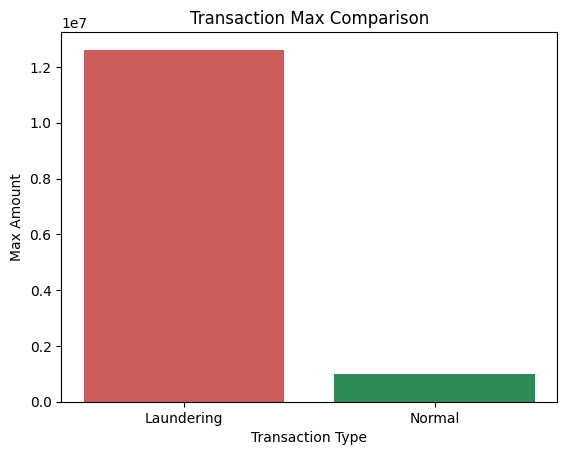

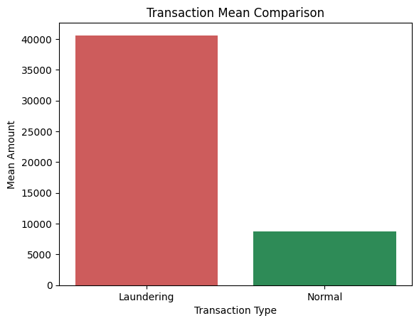

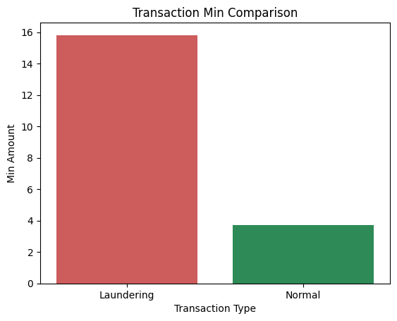

```python
laundering_stats = df[df['Is_laundering'] == 1]['Amount'].agg(['max', 'mean', 'min'])

normal_stats = df[df['Is_laundering'] == 0]['Amount'].agg(['max', 'mean', 'min'])

print("Laundering Transactions Stats:\n", laundering_stats)
print("\nNormal Transactions Stats:\n", normal_stats)

categories = ['Laundering', 'Normal']

# For each statistic, create a separate figure
for stat in ['max', 'mean', 'min']:
    values = [laundering_stats[stat], normal_stats[stat]]
    plt.figure()
    plt.bar(categories, values, color=['indianred', 'seagreen'])
    plt.title(f"Transaction {stat.capitalize()} Comparison")
    plt.xlabel('Transaction Type')
    plt.ylabel(f"{stat.capitalize()} Amount")
    plt.show()
```

### Interpretation

- Laundering transactions tend to be much higher in value than normal transactions—both on average and for maximum amounts.

```
Original Skewness: 102.16408577285024
Log-Transformed Skewness: -1.0103052224946008
```

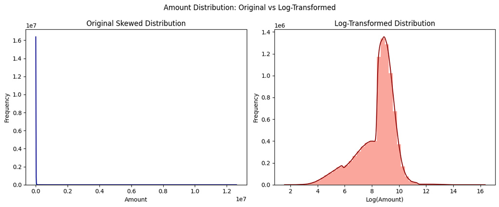

```python
# Data
skewed_data = df['Amount']

original_skewness = skew(skewed_data)
print(f"Original Skewness: {original_skewness}")

# Log transformation
log_transformed_data = np.log1p(skewed_data)
transformed_skewness = skew(log_transformed_data)
print(f"Log-Transformed Skewness: {transformed_skewness}")

fig, axs = plt.subplots(1, 2, figsize=(12, 5))

# Original histogram
axs[0].hist(skewed_data, bins=500, color='skyblue', alpha=0.7, label='Original')

# KDE for original
kde_original = gaussian_kde(skewed_data)
bin_edges = np.histogram_bin_edges(skewed_data, bins=500)
bin_width = bin_edges[1] - bin_edges[0]
x_original = np.linspace(skewed_data.min(), skewed_data.max(), 1000)
axs[0].plot(x_original, kde_original(x_original) * len(skewed_data) * bin_width, color='darkblue', label='KDE Original')

axs[0].set_title("Original Skewed Distribution")
axs[0].set_xlabel("Amount")
axs[0].set_ylabel("Frequency")

# Log-Transformed histogram
axs[1].hist(log_transformed_data, bins=50, color='salmon', alpha=0.7, label='Log-Transformed')

# KDE for log-transformed
kde_log = gaussian_kde(log_transformed_data)
bin_edges_log = np.histogram_bin_edges(log_transformed_data, bins=50)
bin_width_log = bin_edges_log[1] - bin_edges_log[0]
x_log = np.linspace(log_transformed_data.min(), log_transformed_data.max(), 1000)
axs[1].plot(x_log, kde_log(x_log) * len(log_transformed_data) * bin_width_log, color='darkred', label='KDE Log')

axs[1].set_title("Log-Transformed Distribution")
axs[1].set_xlabel("Log(Amount)")
axs[1].set_ylabel("Frequency")

plt.suptitle("Amount Distribution: Original vs Log-Transformed")
plt.tight_layout()
plt.show()
```

## Data prepare

```python
## Dropping some columns

columns_to_drop = ['Time', 'Date']

df.drop(columns=columns_to_drop, inplace=True)

df.columns
```

```
Index(['Sender_account', 'Receiver_account', 'Amount', 'Payment_currency',
       'Received_currency', 'Sender_bank_location', 'Receiver_bank_location',
       'Payment_type', 'Is_laundering', 'Laundering_type', 'Year', 'Month',
       'Day', 'Week'],
      dtype='object')
```

```python
num_cols = df.select_dtypes(exclude="object").columns
categorical_cols = df.select_dtypes(include="object").columns

print(num_cols)
print(categorical_cols)
```

```
Index(['Sender_account', 'Receiver_account', 'Amount', 'Is_laundering', 'Year',
       'Month', 'Day', 'Week'],
      dtype='object')
Index(['Payment_currency', 'Received_currency', 'Sender_bank_location',
       'Receiver_bank_location', 'Payment_type', 'Laundering_type'],
      dtype='object')
```

```python
df.isnull().sum()
```

```
Sender_account            0
Receiver_account          0
Amount                    0
Payment_currency          0
Received_currency         0
Sender_bank_location      0
Receiver_bank_location    0
Payment_type              0
Is_laundering             0
Laundering_type           0
Year                      0
Month                     0
Day                       0
Week                      0
dtype: int64
```

```python
df = df.copy(deep=True)
df.head()
```

|  | Sender_account | Receiver_account | Amount | Payment_currency | Received_currency | Sender_bank_location | Receiver_bank_location | Payment_type | Is_laundering | Laundering_type | Year | Month | Day | Week |
| --- | --- | --- | --- | --- | --- | --- | --- | --- | --- | --- | --- | --- | --- | --- |
| 0 | 8724731955 | 2769355426 | 1459.15 | UK pounds | UK pounds | UK | UK | Cash Deposit | 0 | Normal_Cash_Deposits | 2022 | 10 | 7 | 40 |
| 1 | 1491989064 | 8401255335 | 6019.64 | UK pounds | Dirham | UK | UAE | Cross-border | 0 | Normal_Fan_Out | 2022 | 10 | 7 | 40 |
| 2 | 287305149 | 4404767002 | 14328.44 | UK pounds | UK pounds | UK | UK | Cheque | 0 | Normal_Small_Fan_Out | 2022 | 10 | 7 | 40 |
| 3 | 5376652437 | 9600420220 | 11895.00 | UK pounds | UK pounds | UK | UK | ACH | 0 | Normal_Fan_In | 2022 | 10 | 7 | 40 |
| 4 | 9614186178 | 3803336972 | 115.25 | UK pounds | UK pounds | UK | UK | Cash Deposit | 0 | Normal_Cash_Deposits | 2022 | 10 | 7 | 40 |

```python
y = df['Is_laundering'].astype(int)
X = df.drop(columns=['Is_laundering'])
```

```python
# avoid leakage unless available at inference
if 'Laundering_type' in X.columns:
    X = X.drop(columns=['Laundering_type'])
```

```python
df['_date'] = pd.to_datetime(dict(year=df['Year'], month=df['Month'], day=df['Day']), errors='coerce')
df = df.sort_values('_date').reset_index(drop=True)

df['Amount'] = df['Amount'].astype('float32')
for c in ['Year','Month','Day','Week','Is_laundering']:
    if c in df.columns:
        df[c] = df[c].astype('int32')
```

```python
df['currency_mismatch'] = (df['Payment_currency'] != df['Received_currency']).astype('int8')
df['country_mismatch']  = (df['Sender_bank_location'] != df['Receiver_bank_location']).astype('int8')
df['cross_border']      = df['country_mismatch'].astype('int8')
df['log_amount']        = np.log1p(df['Amount']).astype('float32')

low_card_cats = ['Payment_currency','Received_currency','Sender_bank_location',
                 'Receiver_bank_location','Payment_type']
for c in low_card_cats:
    df[c] = df[c].astype('category')
```

```python
df['sender_prev_txn_count']   = df.groupby('Sender_account').cumcount().astype('int32')
df['receiver_prev_txn_count'] = df.groupby('Receiver_account').cumcount().astype('int32')
df['pair_prev_txn_count']     = df.groupby(['Sender_account','Receiver_account']).cumcount().astype('int32')

# prior cumulative amount (sum) and average amount
df['sender_prev_amount_sum'] = (df.groupby('Sender_account')['Amount'].cumsum() - df['Amount']).astype('float32')
df['receiver_prev_amount_sum'] = (df.groupby('Receiver_account')['Amount'].cumsum() - df['Amount']).astype('float32')

# avoid div by zero; avg over *previous* tx only
den_s = df['sender_prev_txn_count'].replace(0, np.nan)
den_r = df['receiver_prev_txn_count'].replace(0, np.nan)
df['sender_prev_amount_avg'] = (df['sender_prev_amount_sum'] / den_s).fillna(0).astype('float32')
df['receiver_prev_amount_avg'] = (df['receiver_prev_amount_sum'] / den_r).fillna(0).astype('float32')

# time since previous transaction (in days) per entity
df['sender_prev_gap_days'] = df.groupby('Sender_account')['_date'].diff().dt.days.fillna(9999).astype('int32')
df['receiver_prev_gap_days'] = df.groupby('Receiver_account')['_date'].diff().dt.days.fillna(9999).astype('int32')

# prior unique counterparties seen so far
# mark first occurrence of each sender->receiver pair (after sort)
df['is_new_sender_receiver_pair'] = (~df.duplicated(['Sender_account','Receiver_account'])).astype('int8')
df['sender_unique_receivers_prev'] = (
    df.groupby('Sender_account')['is_new_sender_receiver_pair'].cumsum().shift(1).fillna(0).astype('int32')
)

# mark first occurrence of each receiver<-sender pair (after sort)
df['is_new_receiver_sender_pair'] = (~df.duplicated(['Receiver_account','Sender_account'])).astype('int8')
df['receiver_unique_senders_prev'] = (
    df.groupby('Receiver_account')['is_new_receiver_sender_pair'].cumsum().shift(1).fillna(0).astype('int32')
)

# (Optional) normalized amount by sender history
# z = (amt - prev_avg) / prev_std  (approximate: running variance is expensive at this scale)
# We'll use a simple ratio vs average as a light-weight proxy.
df['amount_vs_sender_avg'] = (
    (df['Amount'] / (df['sender_prev_amount_avg'].replace(0, np.nan))).fillna(1.0)
).clip(0, 100).astype('float32')
```

```python
target_col = 'Is_laundering'
y = df[target_col].astype('int8')

# drop raw IDs to avoid memorization/overfit
id_cols = ['Sender_account','Receiver_account']

feature_cols = [
    # numeric & engineered
    'Amount','log_amount',
    'currency_mismatch','country_mismatch','cross_border',
    'sender_prev_txn_count','receiver_prev_txn_count','pair_prev_txn_count',
    'sender_prev_amount_sum','receiver_prev_amount_sum',
    'sender_prev_amount_avg','receiver_prev_amount_avg',
    'sender_prev_gap_days','receiver_prev_gap_days',
    'sender_unique_receivers_prev','receiver_unique_senders_prev',
    'amount_vs_sender_avg',
] + low_card_cats

X = df[feature_cols].copy()
```

```python
cut1 = df['_date'].quantile(0.70)
cut2 = df['_date'].quantile(0.85)

train_idx = df['_date'] <= cut1
val_idx   = (df['_date'] > cut1) & (df['_date'] <= cut2)
test_idx  = df['_date'] > cut2

X_train, y_train = X.loc[train_idx], y.loc[train_idx]
X_val,   y_val   = X.loc[val_idx],   y.loc[val_idx]
X_test,  y_test  = X.loc[test_idx],  y.loc[test_idx]
```

```python
pos = int(y_train.sum())
neg = int(len(y_train) - pos)
scale_pos_weight = max(1.0, neg / max(1, pos))

print(f"Train size: {len(y_train):,} | Positives: {pos:,} ({pos/len(y_train):.4%}) | scale_pos_weight≈{scale_pos_weight:.1f}")
```

```
Train size: 6,661,223 | Positives: 6,774 (0.1017%) | scale_pos_weight≈982.4
```

```python
from sklearn.pipeline import Pipeline
from sklearn.impute import SimpleImputer
from sklearn.preprocessing import RobustScaler, OrdinalEncoder
from sklearn.compose import ColumnTransformer
from sklearn.model_selection import train_test_split
from sklearn.preprocessing import StandardScaler
from sklearn.preprocessing import LabelEncoder

from sklearn import metrics
from xgboost import XGBClassifier
from sklearn.model_selection import GridSearchCV

import numpy as np
from sklearn.model_selection import StratifiedKFold, RandomizedSearchCV
from sklearn.metrics import roc_auc_score, average_precision_score, precision_recall_curve, confusion_matrix, classification_report, accuracy_score, f1_score, roc_curve, brier_score_loss
from scipy.stats import randint, uniform, loguniform
from sklearn.base import BaseEstimator, ClassifierMixin, clone
from sklearn.model_selection import ParameterSampler
from sklearn.metrics import make_scorer
from xgboost import callback
import lightgbm as lgb
from sklearn.calibration import calibration_curve, CalibratedClassifierCV
from lightgbm import LGBMClassifier
```

# Baseline Model

```python
lgbm = LGBMClassifier(
    objective='binary',
    learning_rate=0.03,
    n_estimators=5000,
    num_leaves=64,                   # smaller leaves to prevent overfit
    max_depth=8,                     # cap depth
    min_child_samples=2000,          # large leaves for 9.5M scale
    min_child_weight=1e-3,
    subsample=0.8,
    subsample_freq=1,
    colsample_bytree=0.7,
    reg_alpha=1.0,                   # L1
    reg_lambda=5.0,                  # L2
    max_bin=127,
    scale_pos_weight=scale_pos_weight,
    n_jobs=-1,
    random_state=42,
    verbose=-1
)

cat_features = [c for c in low_card_cats if c in X_train.columns]

callbacks = [
    lgb.early_stopping(stopping_rounds=200),
    lgb.log_evaluation(period=200)
]

lgbm.fit(
    X_train, y_train,
    eval_set=[(X_train, y_train), (X_val, y_val)],
    eval_metric=['auc','average_precision'],
    categorical_feature=cat_features,
    callbacks=callbacks
)

best_iter = lgbm.best_iteration_
print(f"Best iteration: {best_iter}")

def metrics_report(y_true, y_prob, label=""):
    roc = roc_auc_score(y_true, y_prob)
    pr  = average_precision_score(y_true, y_prob)
    brier = brier_score_loss(y_true, y_prob)
    print(f"{label} ROC-AUC: {roc:.4f} | PR-AUC: {pr:.6f} | Brier: {brier:.6f}")

def expected_calibration_error(y_true, y_prob, n_bins=20):
    y_true = np.asarray(y_true, dtype=float)
    y_prob = np.asarray(y_prob, dtype=float)
    bins = np.linspace(0., 1., n_bins+1)
    idx = np.digitize(y_prob, bins) - 1
    ece = 0.0
    N = len(y_true)
    for b in range(n_bins):
        m = idx == b
        if m.any():
            conf = y_prob[m].mean()
            acc = y_true[m].mean()
            ece += (m.mean()) * abs(acc - conf)
    return ece

def precision_recall_at_topk(y_true, y_score, frac=0.005):
    y_true = np.asarray(y_true)
    y_score = np.asarray(y_score)
    k = max(1, int(frac * len(y_score)))
    idx = np.argpartition(-y_score, k-1)[:k]
    precision_at_k = y_true[idx].mean()
    recall_at_k = y_true[idx].sum() / max(1, y_true.sum())
    return precision_at_k, recall_at_k, k

p_val_raw  = lgbm.predict_proba(X_val, num_iteration=best_iter)[:,1]
p_test_raw = lgbm.predict_proba(X_test, num_iteration=best_iter)[:,1]

print("\n=== Pre-calibration ===")
metrics_report(y_val,  p_val_raw,  "Val ")
metrics_report(y_test, p_test_raw, "Test")
print(f"Val  ECE: {expected_calibration_error(y_val,  p_val_raw):.6f}")
print(f"Test ECE: {expected_calibration_error(y_test, p_test_raw):.6f}")

for frac in [0.0005, 0.001, 0.0025, 0.005, 0.01]:
    prec, rec, k = precision_recall_at_topk(y_test, p_test_raw, frac=frac)
    print(f"Pre-cal | Top {frac*100:.2f}% | k={k}: Precision={prec:.4f} Recall={rec:.4f}")

calibrated = CalibratedClassifierCV(lgbm, method='isotonic', cv='prefit')
calibrated.fit(X_val, y_val)

p_val_cal  = calibrated.predict_proba(X_val)[:,1]
p_test_cal = calibrated.predict_proba(X_test)[:,1]

print("\n=== Post-calibration (isotonic) ===")
metrics_report(y_val,  p_val_cal,  "Val ")
metrics_report(y_test, p_test_cal, "Test")
print(f"Val  ECE: {expected_calibration_error(y_val,  p_val_cal):.6f}")
print(f"Test ECE: {expected_calibration_error(y_test, p_test_cal):.6f}")

for frac in [0.0005, 0.001, 0.0025, 0.005, 0.01]:
    prec, rec, k = precision_recall_at_topk(y_test, p_test_cal, frac=frac)
    print(f"Post-cal | Top {frac*100:.2f}% | k={k}: Precision={prec:.4f} Recall={rec:.4f}")
```

```
Training until validation scores don't improve for 200 rounds
[200]	training's auc: 0.985067	training's average_precision: 0.0806074	training's binary_logloss: 0.77428	valid_1's auc: 0.982224	valid_1's average_precision: 0.142923	valid_1's binary_logloss: 0.468987
[400]	training's auc: 0.991094	training's average_precision: 0.097181	training's binary_logloss: 0.548316	valid_1's auc: 0.985194	valid_1's average_precision: 0.168822	valid_1's binary_logloss: 0.307701
[600]	training's auc: 0.993209	training's average_precision: 0.106861	training's binary_logloss: 0.43135	valid_1's auc: 0.988693	valid_1's average_precision: 0.185972	valid_1's binary_logloss: 0.237193
[800]	training's auc: 0.994168	training's average_precision: 0.114971	training's binary_logloss: 0.372764	valid_1's auc: 0.990031	valid_1's average_precision: 0.200713	valid_1's binary_logloss: 0.194855
[1000]	training's auc: 0.994794	training's average_precision: 0.124324	training's binary_logloss: 0.335896	valid_1's auc: 0.990884	valid_1's average_precision: 0.220887	valid_1's binary_logloss: 0.176749
[1200]	training's auc: 0.995194	training's average_precision: 0.132983	training's binary_logloss: 0.309449	valid_1's auc: 0.991269	valid_1's average_precision: 0.238055	valid_1's binary_logloss: 0.16173
[1400]	training's auc: 0.995618	training's average_precision: 0.147492	training's binary_logloss: 0.283501	valid_1's auc: 0.991608	valid_1's average_precision: 0.268918	valid_1's binary_logloss: 0.150088
[1600]	training's auc: 0.995973	training's average_precision: 0.161063	training's binary_logloss: 0.264337	valid_1's auc: 0.991893	valid_1's average_precision: 0.297328	valid_1's binary_logloss: 0.140238
[1800]	training's auc: 0.996249	training's average_precision: 0.170926	training's binary_logloss: 0.247983	valid_1's auc: 0.992048	valid_1's average_precision: 0.312899	valid_1's binary_logloss: 0.132628
[2000]	training's auc: 0.996486	training's average_precision: 0.181223	training's binary_logloss: 0.234774	valid_1's auc: 0.992198	valid_1's average_precision: 0.33063	valid_1's binary_logloss: 0.126284
[2200]	training's auc: 0.996734	training's average_precision: 0.195013	training's binary_logloss: 0.222364	valid_1's auc: 0.992318	valid_1's average_precision: 0.354959	valid_1's binary_logloss: 0.119203
[2400]	training's auc: 0.99693	training's average_precision: 0.2041	training's binary_logloss: 0.211985	valid_1's auc: 0.992401	valid_1's average_precision: 0.368133	valid_1's binary_logloss: 0.11391
[2600]	training's auc: 0.99715	training's average_precision: 0.220994	training's binary_logloss: 0.19984	valid_1's auc: 0.992541	valid_1's average_precision: 0.396738	valid_1's binary_logloss: 0.107581
[2800]	training's auc: 0.997311	training's average_precision: 0.230282	training's binary_logloss: 0.189297	valid_1's auc: 0.992639	valid_1's average_precision: 0.408936	valid_1's binary_logloss: 0.102895
[3000]	training's auc: 0.997481	training's average_precision: 0.241804	training's binary_logloss: 0.178814	valid_1's auc: 0.992776	valid_1's average_precision: 0.423737	valid_1's binary_logloss: 0.0978179
[3200]	training's auc: 0.997616	training's average_precision: 0.251583	training's binary_logloss: 0.170191	valid_1's auc: 0.992937	valid_1's average_precision: 0.437239	valid_1's binary_logloss: 0.0931454
[3400]	training's auc: 0.99774	training's average_precision: 0.260387	training's binary_logloss: 0.161967	valid_1's auc: 0.993036	valid_1's average_precision: 0.44844	valid_1's binary_logloss: 0.0891224
[3600]	training's auc: 0.997863	training's average_precision: 0.270781	training's binary_logloss: 0.153685	valid_1's auc: 0.993166	valid_1's average_precision: 0.460732	valid_1's binary_logloss: 0.0851179
[3800]	training's auc: 0.998011	training's average_precision: 0.285471	training's binary_logloss: 0.143496	valid_1's auc: 0.993133	valid_1's average_precision: 0.48212	valid_1's binary_logloss: 0.0791413
Early stopping, best iteration is:
[3610]	training's auc: 0.997871	training's average_precision: 0.271334	training's binary_logloss: 0.153344	valid_1's auc: 0.993179	valid_1's average_precision: 0.461308	valid_1's binary_logloss: 0.084936
Best iteration: 3610

=== Pre-calibration ===
Val  ROC-AUC: 0.9928 | PR-AUC: 0.270794 | Brier: 0.003322
Test ROC-AUC: 0.9943 | PR-AUC: 0.304280 | Brier: 0.003701
Val  ECE: 0.001489
Test ECE: 0.001701
Pre-cal | Top 0.05% | k=706: Precision=0.2890 Recall=0.1212
Pre-cal | Top 0.10% | k=1412: Precision=0.3215 Recall=0.2698
Pre-cal | Top 0.25% | k=3532: Precision=0.3199 Recall=0.6714
Pre-cal | Top 0.50% | k=7064: Precision=0.2193 Recall=0.9204
Pre-cal | Top 1.00% | k=14128: Precision=0.1110 Recall=0.9317

=== Post-calibration (isotonic) ===
Val  ROC-AUC: 0.9779 | PR-AUC: 0.267784 | Brier: 0.000737
Test ROC-AUC: 0.9796 | PR-AUC: 0.300609 | Brier: 0.000850
Val  ECE: 0.000002
Test ECE: 0.000105
Post-cal | Top 0.05% | k=706: Precision=0.3399 Recall=0.1426
Post-cal | Top 0.10% | k=1412: Precision=0.3088 Recall=0.2591
Post-cal | Top 0.25% | k=3532: Precision=0.3213 Recall=0.6744
Post-cal | Top 0.50% | k=7064: Precision=0.2193 Recall=0.9204
Post-cal | Top 1.00% | k=14128: Precision=0.1111 Recall=0.9323
```

```python
import os
def _ensure_dir(path="figures"):
    os.makedirs(path, exist_ok=True)
    return path


def _prevalence(y):
    y = np.asarray(y).astype(int)
    return y.mean() if len(y) else 0.0


def plot_roc(y, yhat_dict, title_prefix, save=True):
    """yhat_dict: {label: scores} (e.g., {"pre": p_raw, "post": p_cal})."""
    plt.figure(figsize=(6, 5))
    for label, scores in yhat_dict.items():
        fpr, tpr, _ = roc_curve(y, scores)
        auc = roc_auc_score(y, scores)
        plt.plot(fpr, tpr, label=f"{label} (AUC={auc:.4f})")
    plt.plot([0,1],[0,1], linestyle='--')
    plt.xlabel('False Positive Rate')
    plt.ylabel('True Positive Rate')
    plt.title(f'{title_prefix} ROC Curves')
    plt.legend(loc='lower right')
    plt.tight_layout()
    if save:
        plt.savefig(os.path.join(_ensure_dir(), f"{title_prefix.lower().replace(' ','_')}_roc.png"), dpi=150)
    plt.show()


def plot_pr(y, yhat_dict, title_prefix, save=True):
    base = _prevalence(y)
    plt.figure(figsize=(6, 5))
    for label, scores in yhat_dict.items():
        precision, recall, _ = precision_recall_curve(y, scores)
        ap = average_precision_score(y, scores)
        plt.plot(recall, precision, label=f"{label} (AP={ap:.3f})")
    plt.hlines(base, 0, 1, linestyles='--', label=f'Baseline ({base:.4%})')
    plt.xlabel('Recall')
    plt.ylabel('Precision')
    plt.title(f'{title_prefix} Precision–Recall Curves')
    plt.legend(loc='upper right')
    plt.tight_layout()
    if save:
        plt.savefig(os.path.join(_ensure_dir(), f"{title_prefix.lower().replace(' ','_')}_pr.png"), dpi=150)
    plt.show()


def plot_reliability(y, yhat_dict, title_prefix, n_bins=30, save=True):
    plt.figure(figsize=(6,5))
    for label, scores in yhat_dict.items():
        frac_pos, mean_pred = calibration_curve(y, scores, n_bins=n_bins, strategy='uniform')
        plt.plot(mean_pred, frac_pos, marker='o', label=f"{label}")
    plt.plot([0,1],[0,1], linestyle='--')
    plt.xlabel('Predicted probability')
    plt.ylabel('Observed frequency')
    plt.title(f'{title_prefix} Reliability (Calibration)')
    plt.legend(loc='upper left')
    plt.tight_layout()
    if save:
        plt.savefig(os.path.join(_ensure_dir(), f"{title_prefix.lower().replace(' ','_')}_calibration.png"), dpi=150)
    plt.show()


def plot_score_hist(y, yhat, title_prefix, sample=2_000_000, bins=100, save=True):
    """Histogram of scores for positives/negatives. Subsamples for speed if needed."""
    y = np.asarray(y).astype(int)
    yhat = np.asarray(yhat)
    n = len(y)
    if n > sample:
        rng = np.random.RandomState(42)
        idx = rng.choice(n, size=sample, replace=False)
        y, yhat = y[idx], yhat[idx]
    plt.figure(figsize=(6,5))
    plt.hist(yhat[y==0], bins=bins, alpha=0.6, density=True, label='Non‑laundering')
    plt.hist(yhat[y==1], bins=bins, alpha=0.6, density=True, label='Suspicious')
    plt.yscale('log')
    plt.xlabel('Score')
    plt.ylabel('Density (log scale)')
    plt.title(f'{title_prefix} Score Distribution by Class')
    plt.legend()
    plt.tight_layout()
    if save:
        plt.savefig(os.path.join(_ensure_dir(), f"{title_prefix.lower().replace(' ','_')}_score_hist.png"), dpi=150)
    plt.show()


def _topk_metrics_curve(y, scores, fracs=None):
    if fracs is None:
        fracs = np.unique(np.concatenate([
            np.linspace(0.0005, 0.01, 20),
            np.array([0.0005, 0.001, 0.0025, 0.005, 0.01])
        ]))
    y = np.asarray(y).astype(int)
    scores = np.asarray(scores)
    order = np.argsort(-scores)
    y_sorted = y[order]
    cum_pos = np.cumsum(y_sorted)
    total_pos = max(1, y.sum())
    n = len(y)
    prec, rec = [], []
    for f in fracs:
        k = max(1, int(f * n))
        tp_at_k = cum_pos[k-1]
        prec.append(tp_at_k / k)
        rec.append(tp_at_k / total_pos)
    return fracs, np.array(prec), np.array(rec)


def plot_topk_curves(y, yhat_dict, title_prefix, save=True):
    plt.figure(figsize=(6,5))
    for label, scores in yhat_dict.items():
        fracs, prec, _ = _topk_metrics_curve(y, scores)
        plt.plot(fracs*100, prec, label=f"{label}")
    plt.xlabel('Top fraction reviewed (%)')
    plt.ylabel('Precision at top‑K')
    plt.title(f'{title_prefix} Precision vs Review Size')
    plt.tight_layout()
    plt.legend()
    if save:
        plt.savefig(os.path.join(_ensure_dir(), f"{title_prefix.lower().replace(' ','_')}_topk_precision.png"), dpi=150)
    plt.show()

    plt.figure(figsize=(6,5))
    for label, scores in yhat_dict.items():
        fracs, _, rec = _topk_metrics_curve(y, scores)
        plt.plot(fracs*100, rec, label=f"{label}")
    plt.xlabel('Top fraction reviewed (%)')
    plt.ylabel('Recall at top‑K')
    plt.title(f'{title_prefix} Recall vs Review Size')
    plt.tight_layout()
    plt.legend()
    if save:
        plt.savefig(os.path.join(_ensure_dir(), f"{title_prefix.lower().replace(' ','_')}_topk_recall.png"), dpi=150)
    plt.show()


def plot_cumulative_gains(y, yhat_dict, title_prefix, save=True):
    plt.figure(figsize=(6,5))
    for label, scores in yhat_dict.items():
        order = np.argsort(-scores)
        y_sorted = np.asarray(y).astype(int)[order]
        cum_pos_rate = np.cumsum(y_sorted) / max(1, np.sum(y_sorted))
        x = np.linspace(0, 1, len(cum_pos_rate))
        plt.plot(x, cum_pos_rate, label=label)
    plt.plot([0,1],[0,1], linestyle='--')
    plt.xlabel('Share of transactions reviewed')
    plt.ylabel('Share of suspicious captured')
    plt.title(f'{title_prefix} Cumulative Capture Curve')
    plt.legend(loc='lower right')
    plt.tight_layout()
    if save:
        plt.savefig(os.path.join(_ensure_dir(), f"{title_prefix.lower().replace(' ','_')}_cumulative_capture.png"), dpi=150)
    plt.show()


def plot_feature_importance(lgbm_model, feature_names, top_n=20, save=True, title_prefix='Test'):
    # For sklearn API, use booster_.feature_importance('gain') for stable ordering
    booster = lgbm_model.booster_
    gain = booster.feature_importance(importance_type='gain')
    names = booster.feature_name()
    # Map back to requested feature_names if provided; otherwise use booster names
    imp_pairs = sorted(zip(names, gain), key=lambda x: x[1], reverse=True)[:top_n]
    labels = [p[0] for p in imp_pairs][::-1]
    values = [p[1] for p in imp_pairs][::-1]
    plt.figure(figsize=(7, max(3, 0.35*top_n)))
    plt.barh(labels, values)
    plt.xlabel('Gain')
    plt.title(f'{title_prefix} Top-{top_n} Feature Importance (gain)')
    plt.tight_layout()
    if save:
        plt.savefig(os.path.join(_ensure_dir(), f"{title_prefix.lower().replace(' ','_')}_feature_importance.png"), dpi=150)
    plt.show()


def plot_training_curves(lgbm_model, save=True):
    if not hasattr(lgbm_model, 'evals_result_'):
        print('No evals_result_ found on model; training curves unavailable.')
        return
    er = lgbm_model.evals_result_
    # Expected keys: {'validation_0': {'auc': [...], 'average_precision': [...], 'binary_logloss': [...]}, 'validation_1': {...}}
    for metric in ['auc', 'average_precision', 'binary_logloss']:
        if all(metric in er[k] for k in er):
            plt.figure(figsize=(6,5))
            for name, v in er.items():
                yvals = v[metric]
                xvals = np.arange(1, len(yvals)+1)
                plt.plot(xvals, yvals, label=name)
            plt.xlabel('Iteration')
            plt.ylabel(metric)
            plt.title(f'Training curves — {metric}')
            plt.legend()
            plt.tight_layout()
            if save:
                plt.savefig(os.path.join(_ensure_dir(), f"training_curve_{metric}.png"), dpi=150)
            plt.show()

# ----------------------
# Driver — call these after training
# ----------------------

def generate_all_plots(X_val=None, y_val=None, X_test=None, y_test=None,
                        p_val_raw=None, p_test_raw=None,
                        p_val_cal=None, p_test_cal=None,
                        lgbm_model=None, feature_names=None):
    """Generate and save all figures for validation and test sets."""
    # Validation set
    if y_val is not None and p_val_raw is not None and p_val_cal is not None:
        plot_roc(y_val, {"pre-cal": p_val_raw, "post-cal": p_val_cal}, 'Validation')
        plot_pr(y_val, {"pre-cal": p_val_raw, "post-cal": p_val_cal}, 'Validation')
        plot_reliability(y_val, {"pre-cal": p_val_raw, "post-cal": p_val_cal}, 'Validation')
        plot_score_hist(y_val, p_val_raw, 'Validation (pre-cal)')
        plot_score_hist(y_val, p_val_cal, 'Validation (post-cal)')
        plot_topk_curves(y_val, {"pre-cal": p_val_raw, "post-cal": p_val_cal}, 'Validation')
        plot_cumulative_gains(y_val, {"pre-cal": p_val_raw, "post-cal": p_val_cal}, 'Validation')

    # Test set
    if y_test is not None and p_test_raw is not None and p_test_cal is not None:
        plot_roc(y_test, {"pre-cal": p_test_raw, "post-cal": p_test_cal}, 'Test')
        plot_pr(y_test, {"pre-cal": p_test_raw, "post-cal": p_test_cal}, 'Test')
        plot_reliability(y_test, {"pre-cal": p_test_raw, "post-cal": p_test_cal}, 'Test')
        plot_score_hist(y_test, p_test_raw, 'Test (pre-cal)')
        plot_score_hist(y_test, p_test_cal, 'Test (post-cal)')
        plot_topk_curves(y_test, {"pre-cal": p_test_raw, "post-cal": p_test_cal}, 'Test')
        plot_cumulative_gains(y_test, {"pre-cal": p_test_raw, "post-cal": p_test_cal}, 'Test')

    # Training curves & feature importance
    if lgbm_model is not None:
        plot_training_curves(lgbm_model)
        if feature_names is None and hasattr(lgbm_model, 'booster_'):
            feature_names = lgbm_model.booster_.feature_name()
        if feature_names is not None:
            plot_feature_importance(lgbm_model, feature_names, top_n=20, title_prefix='Model')
```

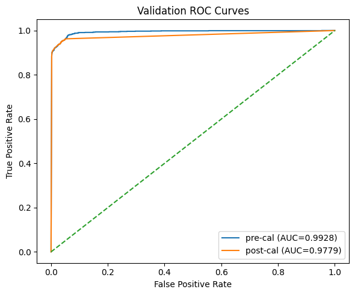

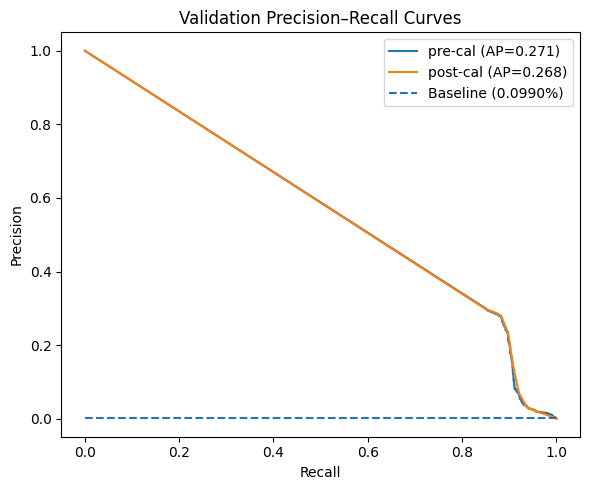

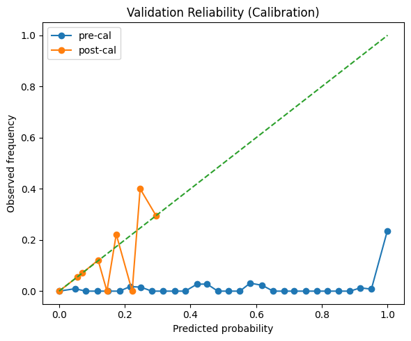

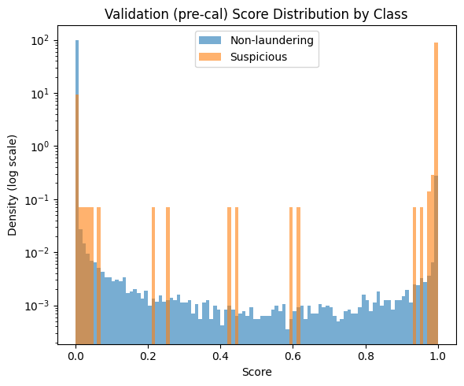

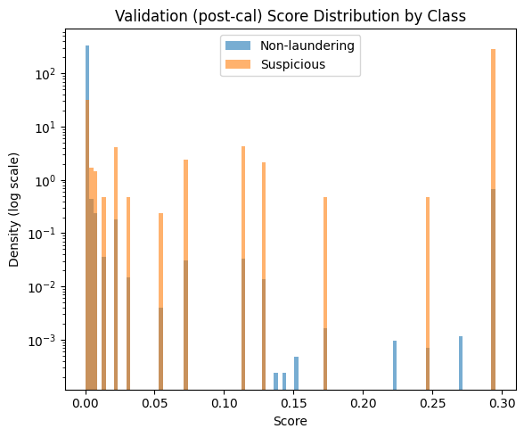

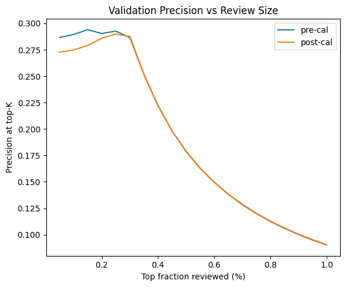

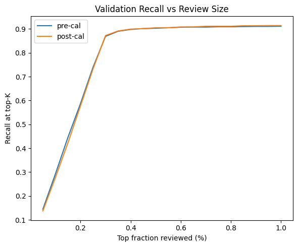

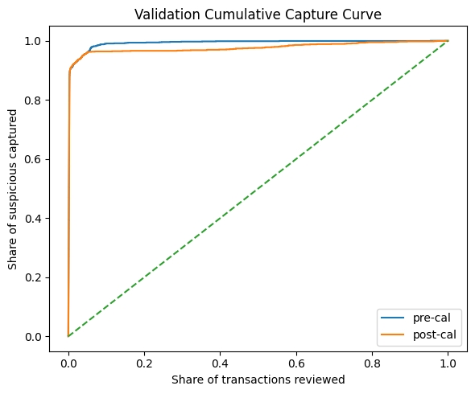

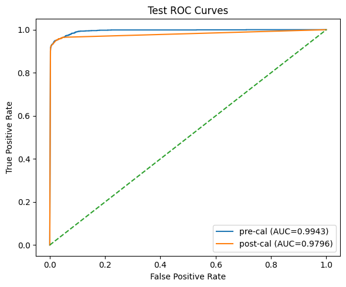

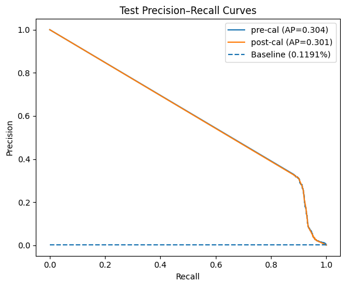

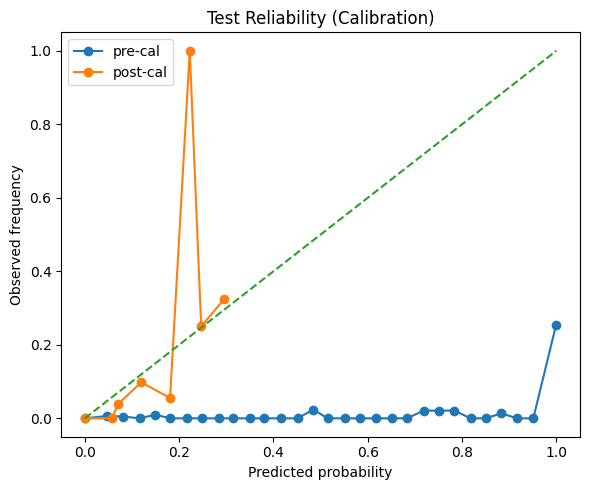

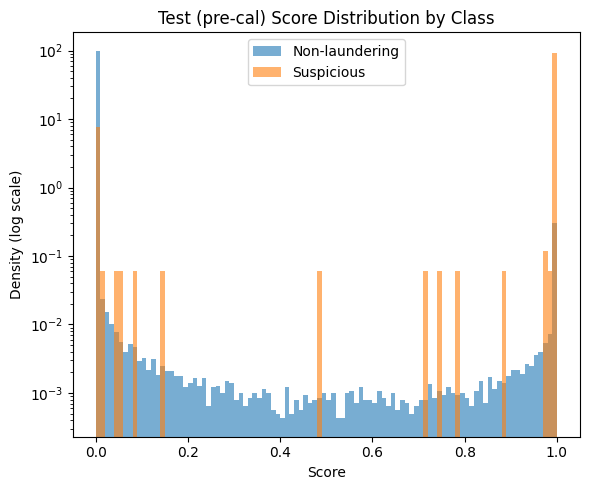

[8 more figures not shown]

```python
generate_all_plots(
     X_val=X_val, y_val=y_val, X_test=X_test, y_test=y_test,
     p_val_raw=p_val_raw, p_test_raw=p_test_raw,
     p_val_cal=p_val_cal, p_test_cal=p_test_cal,
     lgbm_model=lgbm,
     feature_names=list(X_train.columns)
 )
```